# Final Report Essentials

Author

Affiliation

Hien Le

University of Pennsylvania

Published

May 10, 2024

## Introduction

This study examines the intricate relationship between food insecurity and trust in public institutions. The research question is embedded within the broader scholarly discourse, which, while rich, reveals several notable gaps that this paper seeks to address. Studies by Levi et al. and Smith, Kassa, and Wesselbaum provide a foundational understanding of the dynamics at play.

(Levi 2009) investigate the constructs of legitimacy and trust in government, arguing that trustworthiness, procedural justice, and administrative competence are essential for enhancing citizen compliance and deference to authority. Their analysis, based on survey data from various African countries, suggests that perceived government effectiveness in ensuring food security significantly boosts public trust and legal compliance. They propose that effective food security measures are critical for fostering stable and effective governance, as they enhance perceptions of government performance and responsibility. Conversely, (Smith, Kassa, and Wesselbaum 2024) explore how food insecurity directly undermines both horizontal trust (among peers) and vertical trust (in institutions). They argue that food insecurity represents a failure of the social contract, wherein citizens expect the state to provide basic services, such as food security. This breach significantly erodes trust in public institutions. Furthermore,(Bradbury 2024) underscores the importance of transparent communication and the involvement of credible sources in food safety and regulation as key factors in maintaining and enhancing institutional trust.

The literature review indicates a research gap, particularly concerning the geographic scope of Levi’s study, which may limit the generalizability of the findings to other global contexts. There is also a pressing need for broader methodological approaches, as the prevalent use of cross-sectional data does not adequately capture the dynamic fluctuations in food security and institutional trust that occur during global disruptions like pandemics or economic crises. This research aims to bridge these gaps by focusing on the Philippines, conducting a trend analysis that compares data from 2012 and 2019. While Smith et al.’s use of entropy matching effectively balances observed covariates between groups, it does not address unobserved confounders, which could introduce bias. This study will employ a doubly robust method, combining propensity score matching with regression adjustments, to better control for both observed and potentially unobserved confounding variables. This approach aims to enhance the reliability of causal inferences and provide deeper insights into how shifts in food security impact trust in public institutions over time. This, in turn, could inform more effective policy interventions.

## Hypothesis

Refining the broad research question into a specific, testable hypothesis, I propose: “Increased food security leads to enhanced trust in public institutions.” This hypothesis suggests a causal relationship wherein improvements in food security (the independent variable) are expected to result in higher levels of trust in public institutions (the dependent variable).

My hypothesis is grounded in these findings and extends the logical reasoning by suggesting that as food security is a fundamental need, its assurance by the government should logically enhance the citizens’ trust in its ability to fulfill other basic needs and rights. The validity of this hypothesis will be assessed through a focused study in the Philippines, utilizing comparative data from 2012 and 2019 to observe changes over time. The choice of the Philippines as a research locale provides a unique lens to explore this relationship within a democratic, non-Western setting, characterized by distinct socio-political dynamics. This approach aims to contribute broader insights into the causal dynamics between food security and trust in public institutions.

## Research design

### 1. Data description

The dataset employed for this analysis is derived from the World Values Survey (WVS), specifically from Wave 7, which spans the period from 2017 to 2022. This study focuses on data collected in the Philippines during 2019, in accordance with the [master questionnaire](https://www.worldvaluessurvey.org/WVSDocumentationWV7.jsp) established by the WVS. The survey employs random probability sampling techniques to ensure a sample representative of the adult population of each participating country. In the Philippines, the data collection was executed primarily through face-to-face interviews, utilizing either paper-assisted personal interviewing (PAPI) or computer-assisted personal interviewing (CAPI) methods. The primary unit of analysis within this dataset is the individual respondent, each uniquely identified by an interview ID. Each row of the dataset corresponds to the responses of an individual to a comprehensive set of questions

### 2. Variable Definitions and Data Handling

Independent Variable: Food Security

- Food security is assessed using responses to question Q51: “Gone without having enough food to eat,” with answers ranging numerically from 1 to 4: Often, Sometimes, Rarely, Never. For the purposes of this analysis, these responses will be recoded into a binary variable, where ‘Often’ and ‘Sometimes’ indicate food insecurity, and ‘Rarely’ and ‘Never’ signify food security. This variable operationalizes the theoretical concept that access to adequate food underpins perceptions of government effectiveness and social contract fulfillment, which is central to the hypothesis.

Dependent Variable: Trust in Public Institutions Index

- Trust is measured through responses to questions 64 to 81, which assess respondents’ trust in a variety of public institutions, including the armed forces, the press, television, labor unions, the police, the courts, the government, political parties, parliament, the civil service, universities, elections, banks, environmental organizations, women’s organizations, and charitable or humanitarian organizations. These responses are numerical and will be compiled into an additive index to create a comprehensive measure of trust in public institutions. This index embodies the theoretical concept that public trust is a multifaceted construct reflecting confidence in a range of institutional entities

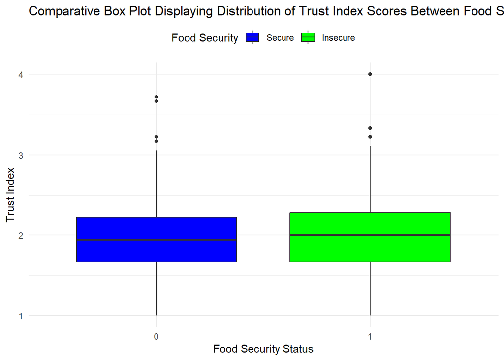

Box plot interpretation

- The provided box plot shows trust index scores for food secure and food insecure groups, highlighting that the median trust index is unexpectedly higher for the food insecure group, challenging the hypothesis that increased food security enhances trust in public institutions. Both groups display a wide range of scores and outliers, suggesting significantly higher trust levels in some individuals. The food insecure group shows a wider interquartile range and greater variability, indicating more diverse trust levels. These findings imply a complex interaction between food security and trust, possibly influenced by unaccounted factors.

Control Variables:

- A range of demographic and socio-economic factors will be included as control variables in the analysis. These factors are gender (Q260), age (Q262), marital status (Q273), education level (Q275), employment status (Q279, Q280), and income level (Q288). All these variables are numerical and will undergo z-score normalization to ensure accurate comparisons and analyses. This normalization process will control for potential confounding factors, allowing for a more precise exploration of the relationship between food security and trust in public institutions.

```
+----+--------------------+----------------------+--------------------+----------------+----------+----------+
| No | Variable           | Stats / Values       | Freqs (% of Valid) | Graph          | Valid    | Missing  |
+====+====================+======================+====================+================+==========+==========+
| 1  | Mean_FoodSecurity\ | Min  : 0\            | 0 : 322 (26.8%)\   | IIIII \        | 1200\    | 0\       |
|    | [numeric]          | Mean : 0.7\          | 1 : 878 (73.2%)    | IIIIIIIIIIIIII | (100.0%) | (0.0%)   |
|    |                    | Max  : 1             |                    |                |          |          |
+----+--------------------+----------------------+--------------------+----------------+----------+----------+
| 2  | Min_FoodSecurity\  | Min  : 0\            | 0 : 322 (26.8%)\   | IIIII \        | 1200\    | 0\       |
|    | [numeric]          | Mean : 0.7\          | 1 : 878 (73.2%)    | IIIIIIIIIIIIII | (100.0%) | (0.0%)   |
|    |                    | Max  : 1             |                    |                |          |          |
+----+--------------------+----------------------+--------------------+----------------+----------+----------+
| 3  | Max_FoodSecurity\  | Min  : 0\            | 0 : 322 (26.8%)\   | IIIII \        | 1200\    | 0\       |
|    | [numeric]          | Mean : 0.7\          | 1 : 878 (73.2%)    | IIIIIIIIIIIIII | (100.0%) | (0.0%)   |
|    |                    | Max  : 1             |                    |                |          |          |
+----+--------------------+----------------------+--------------------+----------------+----------+----------+
| 4  | SD_FoodSecurity\   | All NA's             |                    |                | 0\       | 1200\    |
|    | [numeric]          |                      |                    |                | (0.0%)   | (100.0%) |
+----+--------------------+----------------------+--------------------+----------------+----------+----------+
| 5  | Mean_TrustIndex\   | Mean (sd) : 2 (0.5)\ | 45 distinct values | \ \ \ \ : .\   | 1200\    | 0\       |
|    | [numeric]          | min < med < max:\    |                    | \ \ \ \ : : .\ | (100.0%) | (0.0%)   |
|    |                    | 1 < 1.9 < 4\         |                    | \ \ \ \ : : :\ |          |          |
|    |                    | IQR (CV) : 0.6 (0.2) |                    | . : : : : .\   |          |          |
|    |                    |                      |                    | : : : : : : .  |          |          |
+----+--------------------+----------------------+--------------------+----------------+----------+----------+
| 6  | Min_TrustIndex\    | Mean (sd) : 2 (0.5)\ | 45 distinct values | \ \ \ \ : .\   | 1200\    | 0\       |
|    | [numeric]          | min < med < max:\    |                    | \ \ \ \ : : .\ | (100.0%) | (0.0%)   |
|    |                    | 1 < 1.9 < 4\         |                    | \ \ \ \ : : :\ |          |          |
|    |                    | IQR (CV) : 0.6 (0.2) |                    | . : : : : .\   |          |          |
|    |                    |                      |                    | : : : : : : .  |          |          |
+----+--------------------+----------------------+--------------------+----------------+----------+----------+
| 7  | Max_TrustIndex\    | Mean (sd) : 2 (0.5)\ | 45 distinct values | \ \ \ \ : .\   | 1200\    | 0\       |
|    | [numeric]          | min < med < max:\    |                    | \ \ \ \ : : .\ | (100.0%) | (0.0%)   |
|    |                    | 1 < 1.9 < 4\         |                    | \ \ \ \ : : :\ |          |          |
|    |                    | IQR (CV) : 0.6 (0.2) |                    | . : : : : .\   |          |          |
|    |                    |                      |                    | : : : : : : .  |          |          |
+----+--------------------+----------------------+--------------------+----------------+----------+----------+
| 8  | SD_TrustIndex\     | All NA's             |                    |                | 0\       | 1200\    |
|    | [numeric]          |                      |                    |                | (0.0%)   | (100.0%) |
+----+--------------------+----------------------+--------------------+----------------+----------+----------+
```

### 3. Doubly Robust Method and Limitations

$$\begin{align*}
\text{TrustIndex} = \beta_0 & + \beta_1 \times \text{foodsecurity\_binary} + \beta_2 \times \text{education\_z} \\
& + \beta_3 \times \text{employment\_z} + \beta_4 \times \text{income\_z} + \beta_5 \times \text{sex\_z} \\
& + \beta_6 \times \text{age\_z} + \beta_7 \times \text{mar\_z} + \beta_8 \times \text{children\_z} + \epsilon
\end{align*}$$

To rigorously test the hypothesis that increased food security leads to enhanced trust in public institutions, I am employing a [doubly robust estimation method](https://www.ncbi.nlm.nih.gov/pmc/articles/PMC3070495/#:~:text=Doubly%20robust%20estimation%20combines%20a,an%20exposure%20on%20an%20outcome). (Funk et al. 2011) This advanced statistical approach combines the strengths of propensity score matching and regression analysis, ensuring a robust framework for causal inference. By using this method, the study can produce consistent estimates if at least one of the models (either the propensity score or the outcome regression) is correctly specified. This dual-layer approach mitigates the impact of model misspecification, enhancing the reliability of the findings. Moreover, the doubly robust method is particularly advantageous in observational studies like this one, where random assignment to treatment groups (food security statuses) is not feasible.

In the analysis, several covariates are incorporated to control for potential confounders that could influence the relationship between food security and trust in public institutions. These covariates include:

- **Educational Level (Q275)**: Education could influence both an individual’s perceptions of public institutions and their experiences of food security, making it a crucial factor to account for.
- **Employment Status (Q279)**: Employment directly affects economic stability and, by extension, food security, while also potentially influencing trust in governmental effectiveness.
- **Income Scale (Q288)**: Income level is a direct indicator of economic status, which is likely to affect both an individual’s food security status and their trust in public institutions.
- **Sex (Q260)**: Gender might influence both the experience of food security and perceptions of public trust, necessitating its inclusion as a control variable.
- **Age (Q262)**: Age can affect one’s life experiences, economic status, and outlook on public institutions, thereby impacting both trust and food security.
- **Marital Status (Q273)**: Being married or single could influence living conditions and economic resources, affecting food security and potentially trust in institutions.
- **Number of Children (Q274)**: The presence of dependents likely impacts an individual’s financial priorities and perceptions, including their trust in institutions to provide security.

The decision to include these covariates is driven by their potential to influence both the independent variable (food security) and the dependent variable (trust in public institutions). Controlling for these factors allows the analysis to more accurately isolate the effect of food security on trust levels. While the doubly robust method offers significant strengths in handling model misspecifications and providing reliable estimates, it does have limitations. It relies on the assumption that all relevant confounders are known and correctly modeled, and thus might still be subject to biases if there are unmeasured confounders.

Interpreting the coefficient on food security as a causal effect on trust in public institutions can be threatened by unobserved confounders such as personal experiences with public services, cultural attitudes towards authority, and previous exposure to government interventions, which might not be fully captured in the available covariates. These unmeasured factors could influence both an individual’s level of trust and their food security status, potentially biasing the estimated relationship and complicating the attribution of causality solely to food security.

This approach notably enhances the causal claims from observational data, making it a robust tool for analyzing complex social issues. To address time as a potential confounder, I’m incorporating a trend analysis in my study to examine how patterns of food insecurity and trust evolve over time, thereby strengthening the analysis by considering the time variable.

## Findings

```
Call:
lm(formula = TrustIndex ~ foodsecurity_binary + education_z +
    employment_z + income_z + sex_z + age_z + mar_z + children_z,
    data = matched_data)

Residuals:
     Min       1Q   Median       3Q      Max
-1.17004 -0.29220 -0.00879  0.29668  2.10763

Coefficients:
                     Estimate Std. Error t value Pr(>|t|)
(Intercept)          1.957070   0.028288  69.183  < 2e-16 ***
foodsecurity_binary  0.020364   0.032148   0.633 0.526564
education_z          0.051607   0.013859   3.724 0.000206 ***
employment_z         0.019818   0.013928   1.423 0.155047
income_z             0.007078   0.014093   0.502 0.615591
sex_z                0.001989   0.013772   0.144 0.885195
age_z                0.062960   0.015187   4.146 3.65e-05 ***
mar_z               -0.007201   0.014752  -0.488 0.625551
children_z          -0.023351   0.016639  -1.403 0.160773
---
Signif. codes:  0 '***' 0.001 '**' 0.01 '*' 0.05 '.' 0.1 ' ' 1

Residual standard error: 0.4452 on 1118 degrees of freedom
Multiple R-squared:  0.02908,   Adjusted R-squared:  0.02214
F-statistic: 4.186 on 8 and 1118 DF,  p-value: 5.939e-05
```

### Key Results:

**(Intercept)**: The intercept (1.95707) represents the estimated mean Trust Index when all predictors are held at zero. Since many predictors are standardized (z-scores), this is the mean Trust Index for average values of the control variables.

**(Model Summary)** Moreover, the Adjusted R-squared value (0.02214) suggests that the model explains only a small fraction of the variability in Trust Index, implying that other unmeasured variables might be influencing trust. This further supports the possibility that the model may benefit from additional data or a revised approach to increase the statistical power and better detect subtle effects.

- **foodsecurity_binary**: The coefficient (0.020364) for food security (binary, where 1 represents food insecurity) is not statistically significant (p-value = 0.526564). This suggests that, controlling for other variables in the model, food insecurity does not have a statistically significant impact on trust in public institutions.
- **education_z**, **age_z**: These variables show significant positive effects on Trust Index, indicating that higher levels of education and older age are associated with higher trust in public institutions.
  - **education_z** has a coefficient of 0.051607 (p-value = 0.000206).
  - **age_z** has a coefficient of 0.062960 (p-value = 3.65e-05).
- **Other Variables**: (coefficient: 0.019818, p-value: 0.155047) and income (coefficient: 0.007078, p-value: 0.615591) show non-significant effects. Though not statistically significant, the coefficient for employment suggests a modest positive relationship with the Trust Index, which might be obscured by the large standard errors, indicating possible variability or insufficient power to detect a true effect. Similarly, the negative coefficient for the number of children (coefficient: -0.023351, p-value: 0.160773) may suggest that having more children could marginally decrease trust, though the relationship is not statistically clear and may benefit from further study with a larger sample or different model specifications.

## Empirical Extension

### Key Results for the 2012 data

The doubly robust method was applied for the 2012 using propensity score matching and then linear regressions.

```
Call:
lm(formula = TrustIndex ~ foodsecurity_binary + education_z +
    employment_z + income_z + sex_z + age_z + mar_z + children_z,
    data = matched_data2)

Residuals:
     Min       1Q   Median       3Q      Max
-1.28703 -0.28683 -0.01363  0.27252  1.73375

Coefficients:
                    Estimate Std. Error t value Pr(>|t|)
(Intercept)          2.05775    0.02788  73.802  < 2e-16 ***
foodsecurity_binary  0.08278    0.03222   2.569 0.010325 *
education_z          0.06877    0.01472   4.670 3.39e-06 ***
employment_z        -0.01698    0.01390  -1.222 0.222082
income_z            -0.05063    0.01410  -3.591 0.000344 ***
sex_z                0.01468    0.01377   1.066 0.286667
age_z                0.08007    0.01575   5.083 4.38e-07 ***
mar_z                0.01590    0.01442   1.103 0.270395
children_z          -0.03168    0.01704  -1.859 0.063324 .
---
Signif. codes:  0 '***' 0.001 '**' 0.01 '*' 0.05 '.' 0.1 ' ' 1

Residual standard error: 0.4394 on 1073 degrees of freedom
Multiple R-squared:  0.05513,   Adjusted R-squared:  0.04808
F-statistic: 7.826 on 8 and 1073 DF,  p-value: 2.945e-10
```

**(Intercept)**: The intercept (2.05775) indicates the estimated mean Trust Index when all predictors are set at their reference levels (zero for standardized variables). This is the mean Trust Index for individuals with average characteristics according to the control variables.

**(Model Summary)**: The model for 2012 explains a slightly higher but still modest proportion of the variance in Trust Index (Adjusted R-squared = 0.04808) compared to 2019. This improvement might be due to variations in data collection or external factors influencing trust levels differently across the two periods. The F-statistic (7.826 on 8 and 1073 DF, p-value = 2.945e-10) supports the model’s overall significance, suggesting that at least some of the predictors reliably influence the Trust Index.

Takeaway: The 2012 data analysis reveals some contrasts with the 2019 results, particularly in the significance and direction of the income effect and the strength of the relationship between food security and trust. These differences underscore the dynamic nature of trust in public institutions and suggest that the factors influencing trust can shift significantly over time, potentially due to economic, political, or social changes.

### Trend analysis

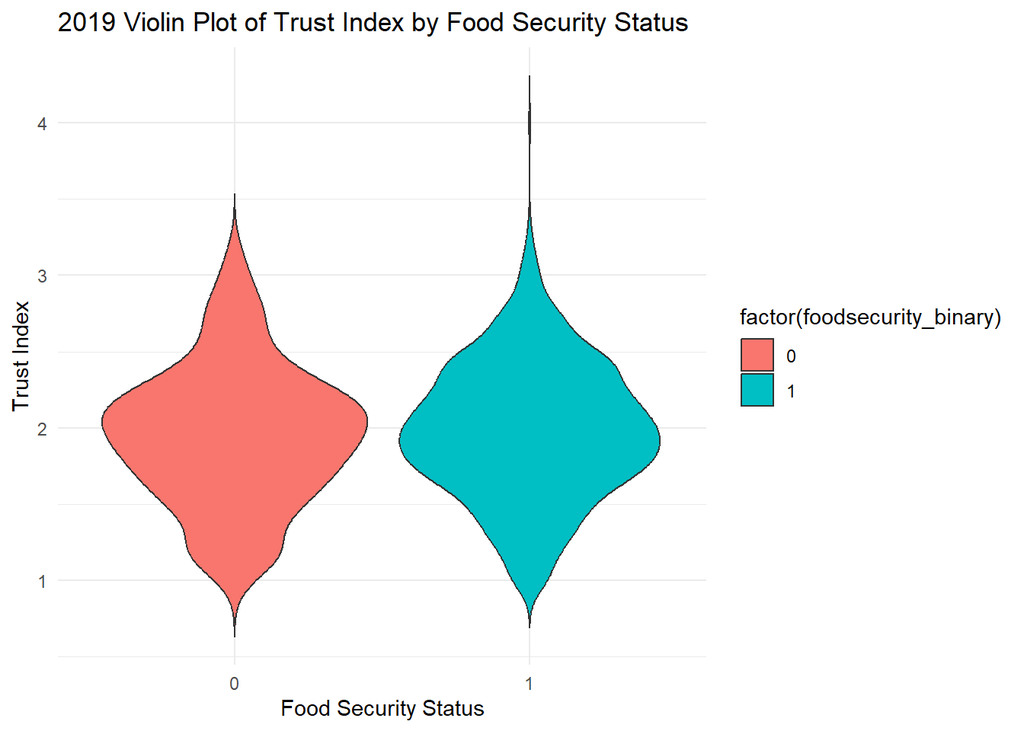

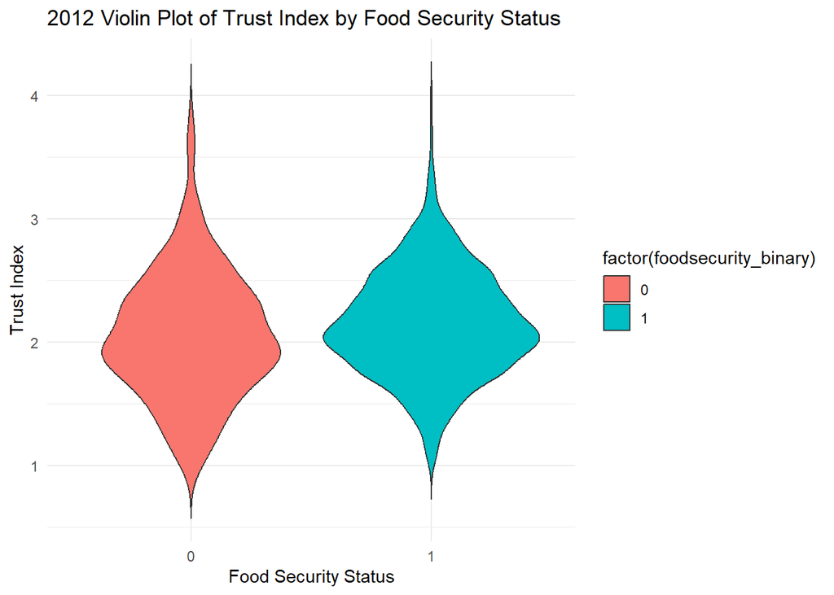

## Discussion

### Takeaway

The inconsistency in the results across different time points suggests that while food security can impact trust, this effect is not straightforward and is likely influenced by other factors such as economic conditions, governmental policies, and public perceptions over time. These findings underscore the complexity of the relationship and highlight the potential limitations of cross-sectional data in capturing the dynamics of trust and food security.

### Policy Implications and Future Research

For policymakers, the implication is clear: interventions to improve food security should not be viewed in isolation. Instead, they should be part of a broader strategy that addresses various dimensions of governance and public service delivery. This approach might include improving the efficiency of public institutions, increasing transparency in government operations, and ensuring that policies are responsive to the needs of the population.

Future research should focus on longitudinal studies that can more accurately track changes over time, possibly integrating qualitative data to capture the nuances of public perception and trust. Additionally, considering other regions with different socio-political contexts could provide a more generalized understanding of how food security influences trust in public institutions globally. Such studies could also explore the role of media and communication strategies by the government in shaping public perceptions, thereby providing a more comprehensive framework for understanding and enhancing public trust.

## References

Bradbury, Author. 2024. “Scientific Literature Review on Measuring Institutional Trust in the Domain of Food Regulation, Food Safety and Public Health Nutrition.” *The European Food Safety Authority*. https://doi.org/https://doi.org/10.2903/sp.efsa.2024.e220301.

Funk, Michele Jonsson, Daniel Westreich, Chris Wiesen, Til Stürmer, M Alan Brookhart, and Marie Davidian. 2011. “Doubly Robust Estimation of Causal Effects.” *American Journal of Epidemiology* 173 (7): 761–67. https://doi.org/10.1093/aje/kwq439.

Levi, Author. 2009. “Conceptualizing Legitimacy, Measuring Legitimating Beliefs.” *American Behavioral Scientist* 53(3) (1): 354–75. https://doi.org/https://doi.org/10.1177/0002764209338797.

Smith, Michael D., Woubet Kassa, and Dennis Wesselbaum. 2024. “Food Insecurity Erodes Trust.” *Global Food Security* 40: 100742. https://doi.org/https://doi.org/10.1016/j.gfs.2024.100742.